# Word Frequency Analysis

Text Mining

Description for Word Frequency Analysis

Yeongeun Jeon , Jung In Seo  
2023-10-01

- **참고 : Do it! 쉽게 배우는 R 텍스트 마이닝**

# **패키지 설치**

```r
pacman::p_load("stringr",
               "dplyr",
             "tidytext",
               "ggplot2", "ggwordcloud",
               "showtext")
```

# **1. 텍스트 전처리**

- 텍스트 전처리 : 텍스트를 분석하는 데 불필요한 요소를 제거하고 다루기 쉬운 형태로 만드는 과정
- 텍스트 분석에서는 전처리에 따라 분석 결과가 크게 달라지기 때문에 매우 중요하다.

## **1-1. 불필요한 문자 제거**

- Package `"stringr"`의 함수 `str_replace_all(string, pattern, replacement)` : 텍스트에서 특정 규칙에 해당하는 문자를 찾아 다른 문자로 바꾸는 함수
  - `string` : 처리할 텍스트
  - `pattern` : 규칙
  - `replacement` : 변경할 문자

```r
txt <- "치킨은!! 맛있다. xyz 정말 맛있다!@#"
txt
```

```
[1] "치킨은!! 맛있다. xyz 정말 맛있다!@#"
```

```r
str_replace_all(string = txt,
                pattern = "[^가-힣]",    # [^가-힣] : 한글을 제외한 모든 문자를 의미하는 정규 표현식
                replacement = " ")       # 공백으로 변경
```

```
[1] "치킨은   맛있다      정말 맛있다   "
```

`Result!` `replacement`에 공백 `" "`을 입력하여 한글을 제외한 모든 문자는 제거한다.

`Caution!` 정규 표현식은 특정한 규칙을 가진 문자열을 표현하는 언어이며, 특정 조건에 해당하는 문자를 찾거나 수정할 때 활용한다. 유용하게 사용하는 정규 표현식은 아래와 같다.

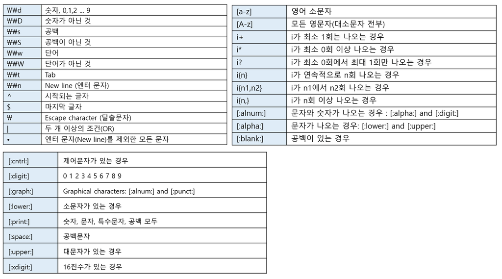

## **1-2. 연속된 공백 제거**

- Package `"stringr"`의 함수 `str_squish` : 연속된 공백을 제거하고 공백을 하나만 남기는 함수

```r
txt <- "치킨은   맛있다   정말 맛있다"
txt
```

```
[1] "치킨은   맛있다   정말 맛있다"
```

```r
str_squish(txt)
```

```
[1] "치킨은 맛있다 정말 맛있다"
```

> **문재인 대통령 대선 출마 연설문을 이용한 텍스트 전처리**
- 함수 `readLines`를 이용하여 텍스트 파일로 저장되어 있는 문재인 대통령 대선 출마 연설문을 불러온다.

```r
# 데이터 불러오기
raw_moon <- readLines(".../speech_moon.txt",
                      encoding = "UTF-8")

head(raw_moon)
```

```
[1] "정권교체 하겠습니다!"
[2] "  정치교체 하겠습니다!"
[3] "  시대교체 하겠습니다!"
[4] "  "
[5] "  ‘불비불명(不飛不鳴)’이라는 고사가 있습니다. 남쪽 언덕 나뭇가지에 앉아, 3년 동안 날지도 울지도 않는 새. 그러나 그 새는 한번 날면 하늘 끝까지 날고, 한번 울면 천지를 뒤흔듭니다."
[6] ""
```

```r
# 1. 불필요한 문자 제거
moon <- str_replace_all(string = raw_moon,
                        pattern = "[^가-힣]",    # [^가-힣] : 한글을 제외한 모든 문자를 의미하는 정규 표현식
                        replacement = " ")       # 공백으로 변경

head(moon)
```

```
[1] "정권교체 하겠습니다 "
[2] "  정치교체 하겠습니다 "
[3] "  시대교체 하겠습니다 "
[4] "  "
[5] "   불비불명       이라는 고사가 있습니다  남쪽 언덕 나뭇가지에 앉아   년 동안 날지도 울지도 않는 새  그러나 그 새는 한번 날면 하늘 끝까지 날고  한번 울면 천지를 뒤흔듭니다 "
[6] ""
```

```r
# 2. 연속된 공백 제거
str_squish(moon)
```

```
  [1] "정권교체 하겠습니다"
  [2] "정치교체 하겠습니다"
  [3] "시대교체 하겠습니다"
  [4] ""
  [5] "불비불명 이라는 고사가 있습니다 남쪽 언덕 나뭇가지에 앉아 년 동안 날지도 울지도 않는 새 그러나 그 새는 한번 날면 하늘 끝까지 날고 한번 울면 천지를 뒤흔듭니다"
  [6] ""
  [7] "그 동안 정치와 거리를 둬 왔습니다 그러나 암울한 시대가 저를 정치로 불러냈습니다 더 이상 남쪽 나뭇가지에 머무를 수 없었습니다 이제 저는 국민과 함께 높이 날고 크게 울겠습니다 오늘 저는 제 대 대통령선거 출마를 국민 앞에 엄숙히 선언합니다"
  [8] ""
  [9] ""
 [10] "우리나라 대통령 이 되겠습니다"
 [11] ""
 [12] ""
 [13] "존경하는 국민 여러분"
 [14] ""
 [15] "저는 대통령이 되겠습니다 우리나라 대통령이 되겠습니다 소수 특권층의 나라가 아니라 보통사람들이 주인인 우리나라 네 편 내 편 편가르지 않고 함께 가는 우리나라 우리 라는 말이 조금도 부끄럽지 않은 진정한 우리나라 의 대통령이 되겠습니다"
```

[output cut: 102 more lines]

```r
head(moon)
```

```
[1] "정권교체 하겠습니다 "
[2] "  정치교체 하겠습니다 "
[3] "  시대교체 하겠습니다 "
[4] "  "
[5] "   불비불명       이라는 고사가 있습니다  남쪽 언덕 나뭇가지에 앉아   년 동안 날지도 울지도 않는 새  그러나 그 새는 한번 날면 하늘 끝까지 날고  한번 울면 천지를 뒤흔듭니다 "
[6] ""
```

```r
## 전처리 작업 한 번에 하기
moon <- raw_moon %>%
 str_replace_all("[^가-힣]", " ") %>%           # 한글을 제외한 모든 문자를 공백으로 변경
 str_squish() %>%                               # 연속된 공백 제거
 as_tibble()                                    # Tibble 형태로 변환

moon
```

```
# A tibble: 117 × 1
   value
   <chr>
 1 "정권교체 하겠습니다"
 2 "정치교체 하겠습니다"
 3 "시대교체 하겠습니다"
 4 ""
 5 "불비불명 이라는 고사가 있습니다 남쪽 언덕 나뭇가지에 앉아 년 동안…
 6 ""
 7 "그 동안 정치와 거리를 둬 왔습니다 그러나 암울한 시대가 저를 정치…
 8 ""
 9 ""
10 "우리나라 대통령 이 되겠습니다"
# ℹ 107 more rows
```

`Caution!` Package `"dplyr"`의 함수 `as_tibble`는 입력한 객체를 Tibble 형태로 변환한다. Tibble은 데이터 프레임(Data Frame)을 다루기 편하게 개선한 형태로 다음과 같은 특징을 가지고 있다.

- 한 행에 한 단락이 들어있다.
- 긴 문장은 Console 창에서 보기 편하게 일부만 출력한다.
- 행과 열의 개수를 알 수 있다.
- 변수의 속성을 알 수 있다.

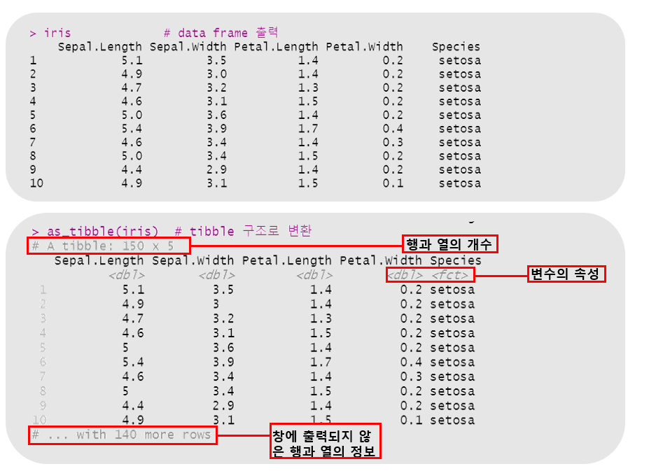

```r
# R에서 제공하는 iris Dataset
data(iris)          # 데이터 불러오기

iris                # Data Frame 형태로 출력
```

```
    Sepal.Length Sepal.Width Petal.Length Petal.Width    Species
1            5.1         3.5          1.4         0.2     setosa
2            4.9         3.0          1.4         0.2     setosa
3            4.7         3.2          1.3         0.2     setosa
4            4.6         3.1          1.5         0.2     setosa
5            5.0         3.6          1.4         0.2     setosa
6            5.4         3.9          1.7         0.4     setosa
7            4.6         3.4          1.4         0.3     setosa
8            5.0         3.4          1.5         0.2     setosa
9            4.4         2.9          1.4         0.2     setosa
10           4.9         3.1          1.5         0.1     setosa
11           5.4         3.7          1.5         0.2     setosa
12           4.8         3.4          1.6         0.2     setosa
13           4.8         3.0          1.4         0.1     setosa
14           4.3         3.0          1.1         0.1     setosa
```

[output cut: 136 more lines]

```r
as_tibble(iris)     # Tibble 형태로 변환
```

```
# A tibble: 150 × 5
   Sepal.Length Sepal.Width Petal.Length Petal.Width Species
          <dbl>       <dbl>        <dbl>       <dbl> <fct>
 1          5.1         3.5          1.4         0.2 setosa
 2          4.9         3            1.4         0.2 setosa
 3          4.7         3.2          1.3         0.2 setosa
 4          4.6         3.1          1.5         0.2 setosa
 5          5           3.6          1.4         0.2 setosa
 6          5.4         3.9          1.7         0.4 setosa
 7          4.6         3.4          1.4         0.3 setosa
 8          5           3.4          1.5         0.2 setosa
 9          4.4         2.9          1.4         0.2 setosa
10          4.9         3.1          1.5         0.1 setosa
# ℹ 140 more rows
```

# **2. 토큰화**

- 토큰(Token) : 텍스트의 기본 단위(ex: 단락, 문장, 단어, 형태소)
- 토큰화 : 텍스트를 토큰으로 나누는 작업
- Package `"tidytext"` : 텍스트를 정돈된 데이터(Tidy Data) 형태로 유지하며 분석할 수 있게 도와주는 패키지
  - 해당 패키지는 Package `"dplyr"`와 `"ggplot2"`를 함께 활용하면 편리하게 텍스트를 분석할 수 있다.
- Package `"tidytext"`의 함수 `unnest_tokens(tbl, input, output, token)`를 이용하여 토큰화를 수행할 수 있다.
  - `tbl` : 데이터 프레임 / Tibble 형태의 데이터
  - `input` : 토큰화를 수행할 텍스트가 포함된 변수명
  - `output` : 출력 변수명
  - `token` : 텍스트를 나누는 기준
    - `sentences` : 문장 기준
    - `words` : 띄어쓰기 기준
    - `characters` : 글자 기준

## **2-1. 문장 기준 토큰화**

```r
# Tibble 형태의 데이터
text <- tibble(value = "대한민국은 민주공화국이다.
               대한민국의 주권은 국민에게 있고,
               모든 권력은 국민으로부터 나온다.")
text
```

```
# A tibble: 1 × 1
  value
  <chr>
1 "대한민국은 민주공화국이다. \n               대한민국의 주권은 국민…
```

```r
# 문장 기준 토큰화
text %>%
  unnest_tokens(input = value,        # 토큰화를 수행할 텍스트가 포함된 변수명
                output = word,        # 출력 변수명
                token = "sentences")  # "sentences" : 문장 기준으로 토큰화
```

```
# A tibble: 2 × 1
  word
  <chr>
1 대한민국은 민주공화국이다.
2 대한민국의 주권은 국민에게 있고,                 모든 권력은 국민으…
```

## **2-2. 띄어쓰기 기준 토큰화**

```r
# Tibble 형태의 데이터
text <- tibble(value = "대한민국은 민주공화국이다.
               대한민국의 주권은 국민에게 있고,
               모든 권력은 국민으로부터 나온다.")
text
```

```
# A tibble: 1 × 1
  value
  <chr>
1 "대한민국은 민주공화국이다. \n               대한민국의 주권은 국민…
```

```r
# 띄어쓰기 기준 토큰화
text %>%
  unnest_tokens(input = value,        # 토큰화를 수행할 텍스트가 포함된 변수명
                output = word,        # 출력 변수명
                token = "words")      # "words" : 띄어쓰기 기준으로 토큰화
```

```
# A tibble: 10 × 1
   word
   <chr>
 1 대한민국은
 2 민주공화국이다
 3 대한민국의
 4 주권은
 5 국민에게
 6 있고
 7 모든
 8 권력은
 9 국민으로부터
10 나온다
```

## **2-3. 글자 기준 토큰화**

```r
# Tibble 형태의 데이터
text <- tibble(value = "대한민국은 민주공화국이다.
               대한민국의 주권은 국민에게 있고,
               모든 권력은 국민으로부터 나온다.")
text
```

```
# A tibble: 1 × 1
  value
  <chr>
1 "대한민국은 민주공화국이다. \n               대한민국의 주권은 국민…
```

```r
# 글자 기준 토큰화
text %>%
  unnest_tokens(input = value,        # 토큰화를 수행할 텍스트가 포함된 변수명
                output = word,        # 출력 변수명
                token = "characters") # "characters" : 글자 기준으로 토큰화
```

```
# A tibble: 40 × 1
   word
   <chr>
 1 대
 2 한
 3 민
 4 국
 5 은
 6 민
 7 주
 8 공
 9 화
10 국
# ℹ 30 more rows
```

> **문재인 대통령 대선 출마 연설문을 이용한 토큰화**

```r
moon                                  # 전처리를 수행한 결과가 저장되어 있는 객체 "moon"
```

```
# A tibble: 117 × 1
   value
   <chr>
 1 "정권교체 하겠습니다"
 2 "정치교체 하겠습니다"
 3 "시대교체 하겠습니다"
 4 ""
 5 "불비불명 이라는 고사가 있습니다 남쪽 언덕 나뭇가지에 앉아 년 동안…
 6 ""
 7 "그 동안 정치와 거리를 둬 왔습니다 그러나 암울한 시대가 저를 정치…
 8 ""
 9 ""
10 "우리나라 대통령 이 되겠습니다"
# ℹ 107 more rows
```

```r
# 1. 문장 기준 토큰화
sentance_space <- moon %>%
  unnest_tokens(input = value,        # 토큰화를 수행할 텍스트가 포함된 변수명
                output = word,        # 출력 변수명
                token = "sentences")  # "sentences" : 문장 기준으로 토큰화
sentance_space
```

```
# A tibble: 59 × 1
   word
   <chr>
 1 정권교체 하겠습니다
 2 정치교체 하겠습니다
 3 시대교체 하겠습니다
 4 불비불명 이라는 고사가 있습니다 남쪽 언덕 나뭇가지에 앉아 년 동안 …
 5 그 동안 정치와 거리를 둬 왔습니다 그러나 암울한 시대가 저를 정치로…
 6 우리나라 대통령 이 되겠습니다
 7 존경하는 국민 여러분
 8 저는 대통령이 되겠습니다 우리나라 대통령이 되겠습니다 소수 특권층…
 9 지금까지 우리 보통사람들은 날지도 울지도 못하는 새였습니다 나라의 …
10 제가 추구하는 우리나라 는 정치인에게 맡겨놓는 나라가 아니라 시민이…
# ℹ 49 more rows
```

```r
# 2. 띄어쓰기 기준 토큰화
word_space <- moon %>%
  unnest_tokens(input = value,        # 토큰화를 수행할 텍스트가 포함된 변수명
                output = word,        # 출력 변수명
                token = "words")      # "words" : 띄어쓰기 기준으로 토큰화
word_space
```

```
# A tibble: 2,025 × 1
   word
   <chr>
 1 정권교체
 2 하겠습니다
 3 정치교체
 4 하겠습니다
 5 시대교체
 6 하겠습니다
 7 불비불명
 8 이라는
 9 고사가
10 있습니다
# ℹ 2,015 more rows
```

```r
# 3. 글자 기준 토큰화
char_space <- moon %>%
  unnest_tokens(input = value,        # 토큰화를 수행할 텍스트가 포함된 변수명
                output = word,        # 출력 변수명
                token = "characters") # "characters" : 글자 기준으로 토큰화
char_space
```

```
# A tibble: 6,517 × 1
   word
   <chr>
 1 정
 2 권
 3 교
 4 체
 5 하
 6 겠
 7 습
 8 니
 9 다
10 정
# ℹ 6,507 more rows
```

# **3. 단어 빈도 분석**

- 단어 빈도 분석(Word Frequency Analysis) : 텍스트에 어떤 단어를 얼마나 사용하였는지 알아보는 분석 방법
  - 자주 사용한 단어를 보면 글쓴이가 무엇을 강조하고자 하는지 알 수 있다.

## **3-1. 단어 빈도 계산**

- Package `"dplyr"`의 함수 `count`를 이용하면 단어의 빈도를 계산할 수 있다.
  - 함수 `count`의 옵션 `sort = T`을 지정하면 빈도가 높은 순(내림차순)으로 단어를 정렬한다.

```r
word_count <- word_space %>%       # 문재인 대통령 대선 출마 연설문을 "띄어쓰기 기준"으로 토큰화한 결과가 저장되어 있는 객체 "word_space"
 count(word,                       # 변수명
       sort = T)                   # 내림차순으로 정렬

word_count
```

```
# A tibble: 1,440 × 2
   word             n
   <chr>        <int>
 1 합니다          27
 2 수              16
 3 있습니다        13
 4 저는            13
 5 등              12
 6 있는            12
 7 함께            12
 8 만들겠습니다    11
 9 일자리          10
10 국민의           9
# ℹ 1,430 more rows
```

`Result!` “합니다”를 27번으로 가장 많이 사용하였고, 그 뒤로는 “수”, “있습니다”를 많이 사용하였다.

## **3-2. 한 글자로 된 단어 제거**

- 한 글자로 된 단어는 어떤 의미로 사용하였는지 파악하기 어렵기 때문에 분석 대상에서 제외하는 게 좋다.
- Package `"stringr"`의 함수 `str_count`를 이용하여 문자열의 글자 수를 계산할 수 있다.

```r
# "배"의 글자 수
str_count("배")
```

```
[1] 1
```

```r
# "사과"의 글자 수
str_count("사과")
```

```
[1] 2
```

```r
word_count1 <- word_count %>%       # 단어 빈도가 저장되어 있는 객체 in 3-1
  filter(str_count(word) > 1)       # 두 글자 이상의 단어만 추출 -> 한 글자로 된 단어 제거

word_count1
```

```
# A tibble: 1,384 × 2
   word             n
   <chr>        <int>
 1 합니다          27
 2 있습니다        13
 3 저는            13
 4 있는            12
 5 함께            12
 6 만들겠습니다    11
 7 일자리          10
 8 국민의           9
 9 우리             9
10 우리나라         9
# ℹ 1,374 more rows
```

`Result!` 함수 `str_count`는 글자 수를 계산하는 함수이고, 함수 `filter`는 조건에 맞는 행만 추출하는 함수이다. 이 두 함수를 이용하여 한 글자로 된 단어를 제거할 수 있다.

## **3-3. 자주 사용한 단어 추출**

```r
# 자주 사용한 상위 20개 단어
top20 <- word_count1 %>%            # 단어 빈도가 내림차순으로 정렬 & 두 글자 이상의 단어만 저장되어 있는 객체
  head(20)                          # 상위 20개의 단어 추출

top20
```

```
# A tibble: 20 × 2
   word             n
   <chr>        <int>
 1 합니다          27
 2 있습니다        13
 3 저는            13
 4 있는            12
 5 함께            12
 6 만들겠습니다    11
 7 일자리          10
 8 국민의           9
 9 우리             9
10 우리나라         9
11 새로운           8
12 위해             8
13 그리고           7
14 나라             7
15 나라가           7
16 지금             7
17 낡은             6
18 대통령이         6
19 되겠습니다       6
20 없는             6
```

## **3-4. 시각화**

### **3-4-1. 막대 그래프**

- Package `"ggplot2"`의 함수 `geom_col`을 이용하면 막대 그래프를 만들 수 있다.
- 막대 그래프를 이용하여 어떤 단어를 얼마나 많이 사용하였는지 쉽게 파악할 수 있다.

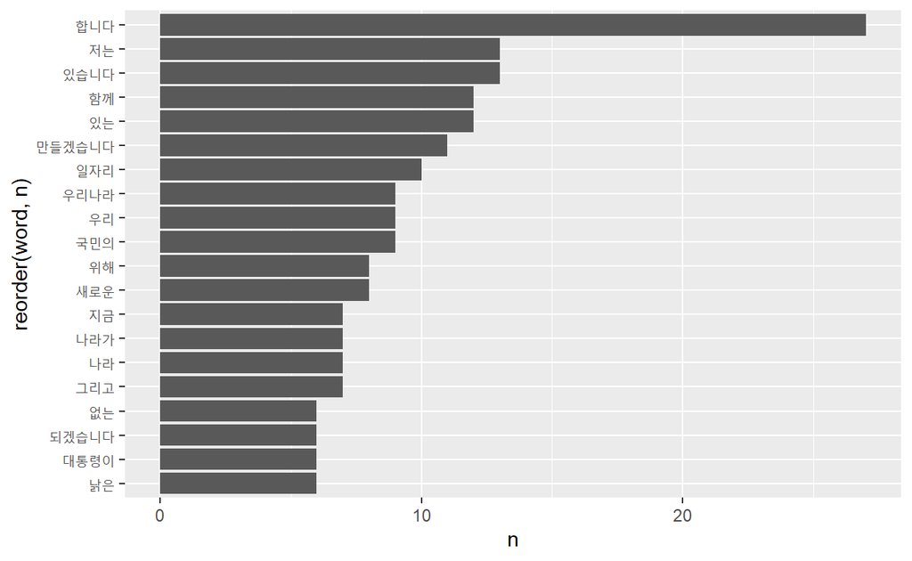

```r
# 기본 막대 그래프
ggplot(top20,                                         # 자주 사용한 상위 20개 단어가 저장되어 있는 객체 in 3-3
       aes(x = reorder(word, n), y = n)) +            # reorder : 단어 빈도순 정렬
  geom_col() +                                        # 막대 그래프
  coord_flip()                                        # 막대를 가로로 회전
```

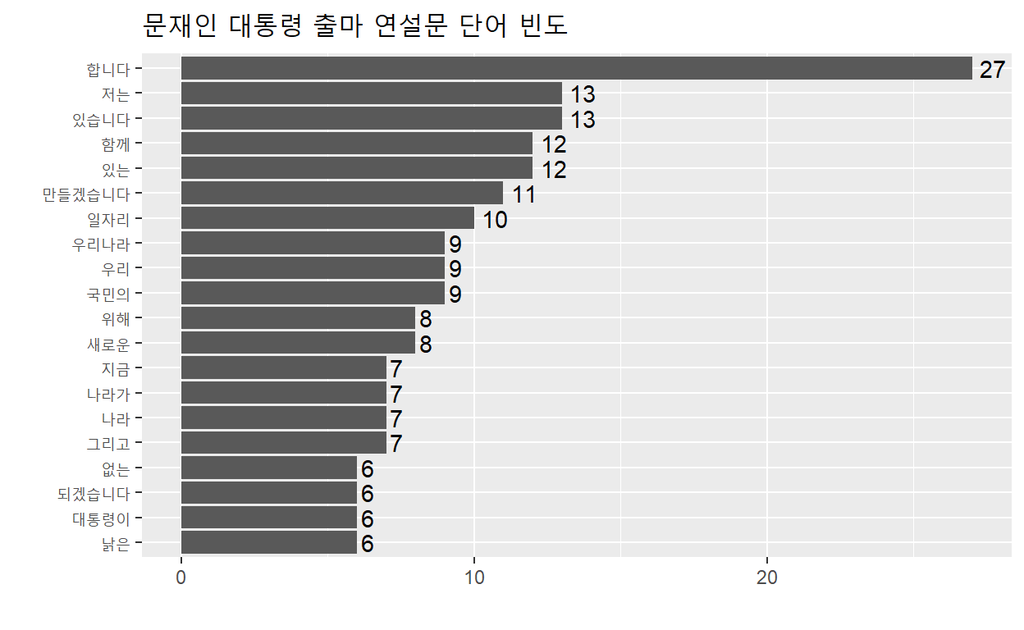

```r
# 그래프 다듬기
ggplot(top20,                                         # 자주 사용한 상위 20개 단어가 저장되어 있는 객체 in 3-3
       aes(x = reorder(word, n), y = n)) +            # reorder : 단어 빈도순 정렬
  geom_col() +                                        # 막대 그래프
  coord_flip() +                                      # 막대를 가로로 회전
  geom_text(aes(label = n), hjust = -0.3) +           # 막대 밖 빈도 표시
  labs(title = "문재인 대통령 출마 연설문 단어 빈도", # 그래프 제목
       x = "", y = "") +                              # x축, y축 이름
  theme(title = element_text(size = 12))              # 그래프 제목 크기
```

#### **그래프 폰트 변경**

그래프의 폰트를 한글 지원 폰트로 바꾸면 한글을 아름답게 표현할 수 있다. Package `"showtext"`의 함수 `font_add_google`을 이용해 [구글 폰트](https://fonts.google.com/)에서 사용할 폰트를 불러온 다음 `showtext_auto()`를 실행해 폰트를 R에서 활용하도록 설정한다. 주의해야할 점은 R을 종료하면 폰트 설정이 사라지기 때문에 시작할 때마다 Package `"showtext"`를 이용하여 구글 폰트를 불러와 설정해야 한다.

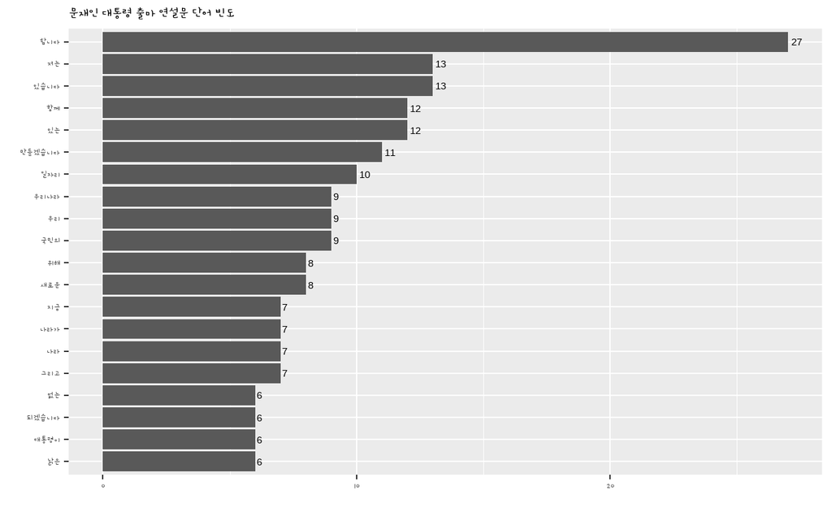

```r
# 감자꽃마을 폰트 불러오기
font_add_google(name = "Gamja Flower",               # 구글 폰트에서 사용하고자 하는 폰트 이름
                family = "gamjaflower")              # R에서 사용할 폰트 이름 -> 사용자 지정
showtext_auto()

# 막대 그래프
ggplot(top20,                                         # 자주 사용한 상위 20개 단어가 저장되어 있는 객체 in 3-3
       aes(x = reorder(word, n), y = n)) +            # reorder : 단어 빈도순 정렬
  geom_col() +                                        # 막대 그래프
  coord_flip() +                                      # 막대를 가로로 회전
  geom_text(aes(label = n), hjust = -0.3) +           # 막대 밖 빈도 표시
  labs(title = "문재인 대통령 출마 연설문 단어 빈도", # 그래프 제목
      x = "", y = "") +                               # x축, y축 이름
  theme(title = element_text(size = 12),              # 그래프 제목 크기
        text = element_text(family = "gamjaflower"))  # 폰트 적용
```

### **3-4-2. 워드 클라우드**

- 워드 클라우드(Word Cloud) : 단어 빈도를 구름 모양으로 표현한 그래프
  - 빈도에 따라 단어 크기와 색을 다르게 표현할 수 있다.
- 워드 클라우드는 Package `"ggwordcloud"`의 함수 `geom_text_wordcloud`를 이용하여 만들 수 있다.
  - 난수를 이용하기 때문에 그래프를 만들 때마다 모양이 바뀌며, 이를 방지하기 위해 “seed” 값을 입력하여 항상 같은 모양을 얻을 수 있다.

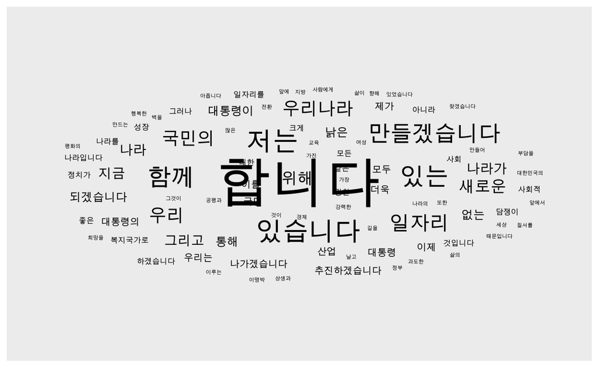

```r
# 기본 워드 클라우드
ggplot(word_count1,                   # 단어 빈도가 내림차순으로 정렬 & 두 글자 이상의 단어만 저장되어 있는 객체 in 3-2
       aes(label = word,
           size = n)) +               # 빈도에 따라 단어의 크기를 다르게 표현
 geom_text_wordcloud(seed = 1234) +   # seed값 입력 -> 항상 같은 모양의 그래프를 출력
 scale_radius(limits = c(3, NA),      # 최소, 최대 단어 빈도
              range = c(3, 30))       # 최소, 최대 글자 크기
```

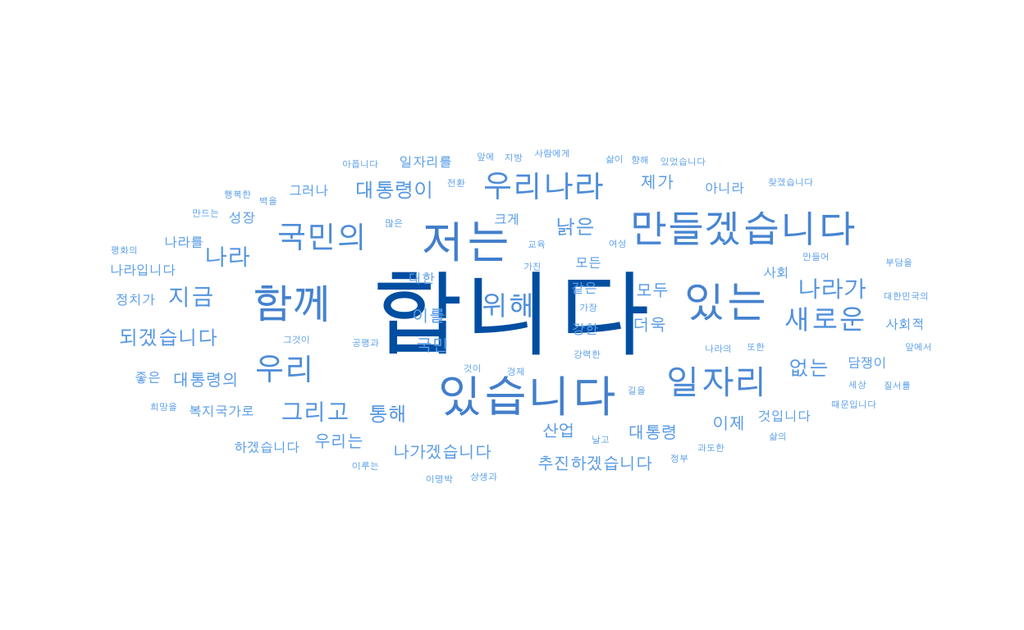

```r
# 그래프 다듬기
ggplot(word_count1,                           # 단어 빈도가 내림차순으로 정렬 & 두 글자 이상의 단어만 저장되어 있는 객체 in 3-2
       aes(label = word,
           size = n,                          # 빈도에 따라 단어의 크기를 다르게 표현
           col = n)) +                        # 빈도에 따라 단어의 색깔을 다르게 표현
  geom_text_wordcloud(seed = 1234) +          # seed값 입력 -> 항상 같은 모양의 그래프를 출력
  scale_radius(limits = c(3, NA),             # 최소, 최대 단어 빈도
               range = c(3, 30)) +            # 최소, 최대 글자 크기
  scale_color_gradient(low = "#66aaf2",       # 최소 빈도 색깔
                       high = "#004EA1") +    # 최고 빈도 색깔
  theme_minimal()                             # 배경 없는 테마 적용
```

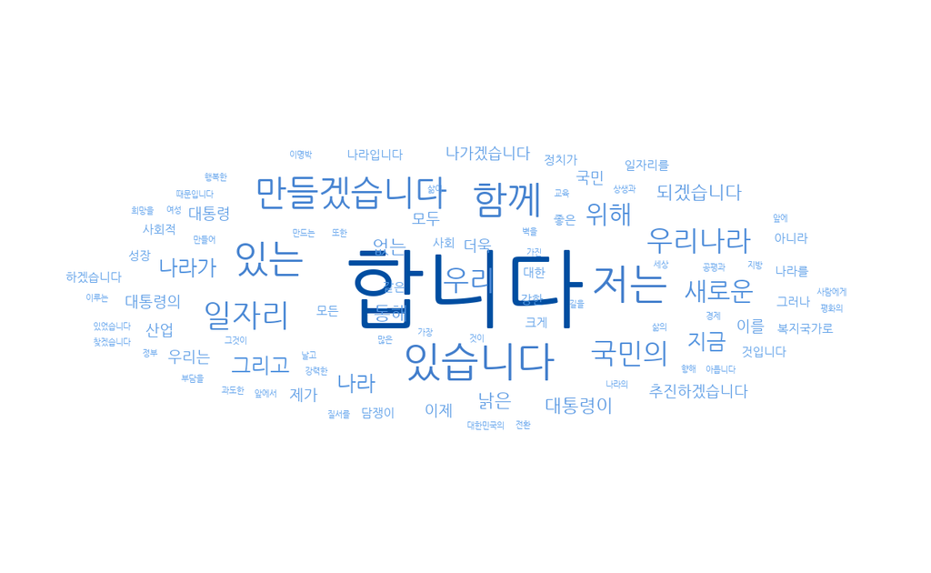

```r
# 그래프 폰트 변경
# 나눔고딕 폰트 불러오기
font_add_google(name = "Nanum Gothic",          # 구글 폰트에서 사용하고자 하는 폰트 이름
                family = "nanumgothic")         # R에서 사용할 폰트 이름 -> 사용자 지정
showtext_auto()

# 워드 클라우드
ggplot(word_count1,                             # 단어 빈도가 내림차순으로 정렬 & 두 글자 이상의 단어만 저장되어 있는 객체 in 3-2
       aes(label = word,
           size = n,                            # 빈도에 따라 단어의 크기를 다르게 표현
           col = n)) +                          # 빈도에 따라 단어의 색깔을 다르게 표현
 geom_text_wordcloud(seed = 1234,               # seed값 입력 -> 항상 같은 모양의 그래프를 출력
                     family = "nanumgothic") +  # 폰트 적용
 scale_radius(limits = c(3, NA),                # 최소, 최대 단어 빈도
              range = c(3, 30)) +               # 최소, 최대 글자 크기
 scale_color_gradient(low = "#66aaf2",          # 최소 빈도 색깔
                      high = "#004EA1") +       # 최고 빈도 색깔
 theme_minimal()                                # 배경 없는 테마 적용
```

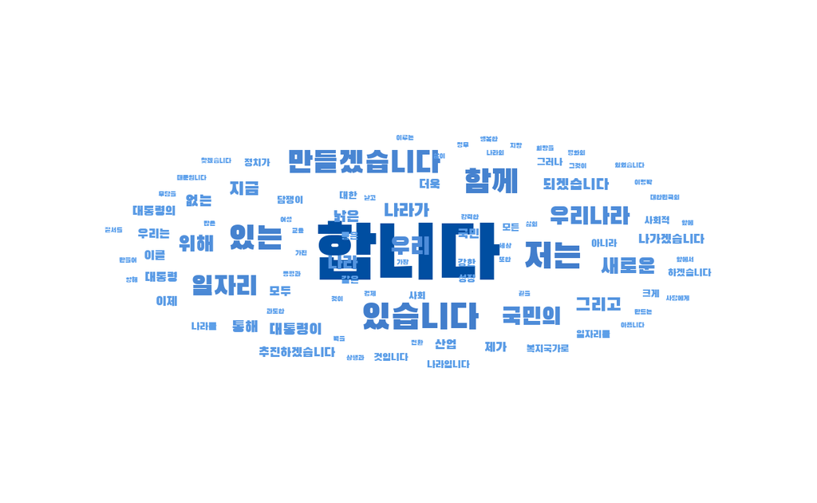

```r
# 검은고딕 폰트 불러오기
font_add_google(name = "Black Han Sans",         # 구글 폰트에서 사용하고자 하는 폰트 이름
                family = "blackhansans")         # R에서 사용할 폰트 이름 -> 사용자 지정
showtext_auto()

# 워드 클라우드
ggplot(word_count1,                              # 단어 빈도가 내림차순으로 정렬 & 두 글자 이상의 단어만 저장되어 있는 객체 in 3-2
       aes(label = word,
           size = n,                             # 빈도에 따라 단어의 크기를 다르게 표현
           col = n)) +                           # 빈도에 따라 단어의 색깔을 다르게 표현
  geom_text_wordcloud(seed = 1234,               # seed값 입력 -> 항상 같은 모양의 그래프를 출력
                      family = "blackhansans") + # 폰트 적용
  scale_radius(limits = c(3, NA),                # 최소, 최대 단어 빈도
               range = c(3, 30)) +               # 최소, 최대 글자 크기
  scale_color_gradient(low = "#66aaf2",          # 최소 빈도 색깔
                       high = "#004EA1") +       # 최고 빈도 색깔
  theme_minimal()                                # 배경 없는 테마 적용
```

`Caution!` 워드 클라우드는 디자인이 아름다워서 자주 사용하지만 분석 결과를 정확하게 표현하는 데는 적합하지 않다. 단어 빈도를 크기와 색으로 표현하므로 “어떤 단어를 몇 번 사용하였는지” 정확히 알 수 없고, 단어 배치가 산만해서 “어떤 단어를 다른 단어보다 얼마나 더 많이 사용하였는지” 비교하기 어렵다. 분석 결과를 정확하게 표현하는 것이 목적이라면 워드 클라우드보다는 막대 그래프를 이용하는 게 좋다.

# **4. 형태소 분석**

- 형태소(Morpheme) : 의미를 지닌 가장 작은 말의 단위
  - 형태소는 더 나누면 뜻이 없는 문자가 된다.
- 형태소 분석(Morphological Analysis) : 문장에서 형태소를 추출해 명사, 동사, 형용사 등 품사로 분류하는 작업
- 띄어쓰기 기준으로 토큰화하면 “합니다”, “있습니다”와 같은 의미를 지니지 않는 서술어가 가장 많이 추출되어 빈도 분석을 해도 텍스트가 무엇을 강조하는 지 알기 어렵기 때문에 한글을 토큰화할 때는 형태소를 기준으로 한다.
  - 특히, 명사는 텍스트가 무엇에 관한 내용인지 파악할 수 있기 때문에 텍스트에서 명사만 추출해 분석할 때가 많다.

## **4-1. 패키지 설치**

- 한글 텍스트의 형태소 분석은 Package `"KoNLP"`를 이용할 수 있다.
  - Package `"KoNLP"`를 설치하기 위해 3가지 과정을 거친다.
    1. 자바와 rJava 설치
    2. Package `"KoNLP"`의 의존성 Package 설치
    3. Package `"KoNLP"` 설치

```r
# 1. 자바와 rJava 설치
install.packages("multilinguer")
library(multilinguer)
install_jdk()
```

```r
# 2. Package "KoNLP"의 의존성 Package 설치
install.packages(c("stringr", "hash", "tau", "Sejong", "RSQLite", "devtools"),
                 type = "binary")
```

```r
# 3. Package "KoNLP" 설치
install.packages("remotes")
library(remotes)
remotes::install_github("haven-jeon/KoNLP",
                        upgrade = "never",
                        INSTALL_opts = c("--no-multiarch"))
library(KoNLP)
```

## **4-2. 형태소 사전 설정**

- Package `"KoNLP"`가 사용하는 “NIA 사전”은 120만여 개 단어로 구성되며, 형태소 분석을 할 때 NIA 사전을 사용하도록 `useNIADic()`를 실행한다.

```r
useNIADic()
```

```
Backup was just finished!
1213109 words dictionary was built.
```

## **4-3. 토큰화**

- Package `"KoNLP"`의 함수 `extractNoun` : 텍스트의 형태소를 분석해 명사를 추출하는 함수
  - 각 문장에서 추출한 명사를 `list` 형태로 출력한다.

```r
# Tibble 형태의 데이터
text <- tibble(
  value = c("대한민국은 민주공화국이다.",
            "대한민국의 주권은 국민에게 있고, 모든 권력은 국민으로부터 나온다."))
text
```

```
# A tibble: 2 × 1
  value
  <chr>
1 대한민국은 민주공화국이다.
2 대한민국의 주권은 국민에게 있고, 모든 권력은 국민으로부터 나온다.
```

```r
extractNoun(text$value)
```

```
[[1]]
[1] "대한민국"   "민주공화국"

[[2]]
[1] "대한민국" "주권"     "국민"     "권력"     "국민"
```

`Caution!` Package `"tidytext"`의 함수 `unnest_tokens` 옵션 `token`에 `extractNoun`를 입력하면 다루기 쉬운 Tibble 형태로 명사를 출력한다.

```r
text %>%
  unnest_tokens(input = value,        # 토큰화를 수행할 텍스트가 포함된 변수명
                output = word,        # 출력 변수명
                token = extractNoun)  # 명사 기준으로 토큰화
```

```
# A tibble: 7 × 1
  word
  <chr>
1 대한민국
2 민주공화국
3 대한민국
4 주권
5 국민
6 권력
7 국민
```

> **문재인 대통령 대선 출마 연설문을 이용한 명사 기준 토큰화**

```r
# Ver.1 : Package `"KoNLP"`의 함수 `extractNoun`
extractNoun(moon$value)                # 전처리를 수행한 결과가 저장되어 있는 객체 "moon"
```

```
[[1]]
[1] "정권교체" "하겠습니"

[[2]]
[1] "정치"     "교체"     "하겠습니"

[[3]]
[1] "시대"     "교체"     "하겠습니"

[[4]]
[1] ""

[[5]]
 [1] "불비불명" "고사"     "남쪽"     "언덕"     "나뭇가지" "년"
 [7] "동안"     "새"       "한"       "번"       "하늘"     "끝"
[13] "한"       "번"       "천지"

[[6]]
[1] ""

[[7]]
 [1] "동안"       "정치"       "거리"       "암울"       "한"
 [6] "시대"       "저"         "정치"       "이상"       "남쪽"
[11] "나뭇가지"   "수"         "저"         "국민"       "오늘"
[16] "저"         "저"         "대"         "대통령선거" "출마"
[21] "국민"       "앞"         "선언"       "합"

[[8]]
[1] ""

[[9]]
[1] ""

[[10]]
[1] "우리나라" "대통령"   "되겠습니"

[[11]]
[1] ""

[[12]]
```

[output cut: 602 more lines]

```

[[114]]
[1] ""

[[115]]
 [1] "저"       "문재인"   "겸손"     "한"       "권력"     "따뜻"
 [7] "한"       "나라"     "국민"     "마음"     "길"       "우리나라"
[13] "대통령"   "우리"     "모두"     "주인"     "진정"     "한"
[19] "우리나라" "대통령"   "되겠습니"

[[116]]
[1] ""

[[117]]
[1] "고맙습니"
```

```r
# Ver.2 : Package `"tidytext"`의 함수 `unnest_tokens`
word_noun <- moon %>%                  # 전처리를 수행한 결과가 저장되어 있는 객체 "moon"
  unnest_tokens(input = value,         # 토큰화를 수행할 텍스트가 포함된 변수명
                output = word,         # 출력 변수명
                token = extractNoun)   # 명사 기준으로 토큰화
word_noun
```

```
# A tibble: 1,757 × 1
   word
   <chr>
 1 "정권교체"
 2 "하겠습니"
 3 "정치"
 4 "교체"
 5 "하겠습니"
 6 "시대"
 7 "교체"
 8 "하겠습니"
 9 ""
10 "불비불명"
# ℹ 1,747 more rows
```

# **5. 명사 빈도 분석**

- 단어 빈도 분석과 동일한 방법으로 수행된다.

```r
# 1. 단어 빈도 계산
word_noun <- word_noun %>%
  count(word, sort = T) %>%    # 단어 빈도를 계산해 내림차순으로 정렬
  filter(str_count(word) > 1)  # 두 글자 이상의 단어만 추출 -> 한 글자로 된 단어 제거

word_noun
```

```
# A tibble: 704 × 2
   word       n
   <chr>  <int>
 1 국민      21
 2 일자리    21
 3 나라      19
 4 우리      17
 5 경제      15
 6 사회      14
 7 성장      13
 8 대통령    12
 9 정치      12
10 하게      12
# ℹ 694 more rows
```

```r
# 2. 자주 사용한 상위 20개 단어
top20 <- word_noun %>%
  head(20)                     # 상위 20개의 단어 추출

top20
```

```
# A tibble: 20 × 2
   word         n
   <chr>    <int>
 1 국민        21
 2 일자리      21
 3 나라        19
 4 우리        17
 5 경제        15
 6 사회        14
 7 성장        13
 8 대통령      12
 9 정치        12
10 하게        12
11 대한민국    11
12 평화        11
13 복지        10
14 우리나라    10
15 확대        10
16 들이         9
17 사람         9
18 산업         9
19 정부         9
20 복지국가     8
```

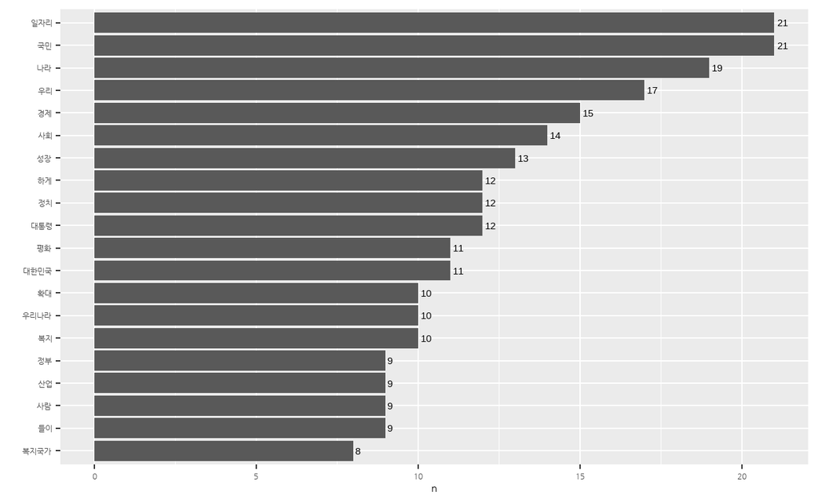

```r
# 3. 시각화
# 3-1. 막대 그래프
# 나눔고딕 폰트 불러오기
font_add_google(name = "Nanum Gothic",                # 구글 폰트에서 사용하고자 하는 폰트 이름
                family = "nanumgothic")               # R에서 사용할 폰트 이름 -> 사용자 지정
showtext_auto()

ggplot(top20,
       aes(x = reorder(word, n), y = n)) +            # reorder : 단어 빈도순 정렬
  geom_col() +                                        # 막대 그래프
  coord_flip() +                                      # 막대를 가로로 회전
  geom_text(aes(label = n), hjust = -0.3) +           # 막대 밖 빈도 표시
  labs(x = "") +                                      # x축 이름
  theme(text = element_text(family = "nanumgothic"))  # 폰트 적용
```

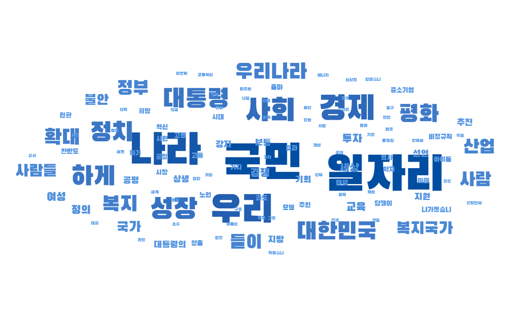

```r
# 3-2. 워드 클라우드
# 검은고딕 폰트 불러오기
font_add_google(name = "Black Han Sans",        # 구글 폰트에서 사용하고자 하는 폰트 이름
                family = "blackhansans")        # R에서 사용할 폰트 이름 -> 사용자 지정
showtext_auto()

ggplot(word_noun, aes(label = word,
                      size = n,                 # 빈도에 따라 단어의 크기를 다르게 표현
                      col = n)) +               # 빈도에 따라 단어의 색깔을 다르게 표현
 geom_text_wordcloud(seed = 1234,               # seed값 입력 -> 항상 같은 모양의 그래프를 출력
                     family = "blackhansans") + # 폰트 적용
 scale_radius(limits = c(3, NA),                # 최소, 최대 단어 빈도
              range = c(3, 30)) +               # 최소, 최대 글자 크기
 scale_color_gradient(low = "#66aaf2",          # 최소 빈도 색깔
                      high = "#004EA1") +       # 최고 빈도 색깔
 theme_minimal()                                # 배경 없는 테마 적용
```

# **6. 특정 단어가 포함된 문장 추출**

- Package `"stringr"`의 함수 `str_detect` : 특정 단어가 문장에 있으면 `TRUE`, 그렇지 않으면 `FALSE`를 반환하는 함수
- 문재인 대통령 대선 출마 연설문을 이용하여 특정 단어가 포함된 문장을 살펴본다.

```r
# 1. 문장 기준으로 토큰화
sentences_moon <- raw_moon %>%
  str_squish() %>%                            # 연속된 공백 제거
  as_tibble() %>%                             # Tibble 형태로 변환
  unnest_tokens(input = value,                # 토큰화를 수행할 텍스트가 포함된 변수명
                output = sentence,            # 출력 변수명
                token = "sentences")          # "sentences" : 문장 기준으로 토큰화

sentences_moon
```

```
# A tibble: 207 × 1
   sentence
   <chr>
 1 정권교체 하겠습니다!
 2 정치교체 하겠습니다!
 3 시대교체 하겠습니다!
 4 ‘불비불명(不飛不鳴)’이라는 고사가 있습니다.
 5 남쪽 언덕 나뭇가지에 앉아, 3년 동안 날지도 울지도 않는 새.
 6 그러나 그 새는 한번 날면 하늘 끝까지 날고, 한번 울면 천지를 뒤흔듭…
 7 그 동안 정치와 거리를 둬 왔습니다.
 8 그러나 암울한 시대가 저를 정치로 불러냈습니다.
 9 더 이상 남쪽 나뭇가지에 머무를 수 없었습니다.
10 이제 저는 국민과 함께 높이 날고 크게 울겠습니다.
# ℹ 197 more rows
```

`Caution!` 문장으로 토큰화를 수행할 때는 마침표가 문장의 기준점이 되므로 특수 문자를 제거하지 않는다.

```r
sentences_moon %>%
  filter(str_detect(sentence, "국민"))        # "국민" 단어가 포함된 문장 추출
```

```
# A tibble: 19 × 1
   sentence
   <chr>
 1 이제 저는 국민과 함께 높이 날고 크게 울겠습니다.
 2 오늘 저는 제18대 대통령선거 출마를 국민 앞에 엄숙히 선언합니다.
 3 존경하는 국민 여러분!
 4 국민이 모두 아픕니다.
 5 국민 한 사람 한 사람이 모두 아픕니다.
 6 국민들에게 희망을 주는 정치가 절실하게 필요합니다.
 7 국민의 뜻이 대통령의 길입니다.
 8 저는 대선출마를 결심하고 국민 여러분께 출마선언문을 함께 쓰자고 제…
 9 시민의 한숨과 눈물을 닦아주지 못하는 정치가 있었고, 오히려 국민의 …
10 상식이 통하는 사회, 권한과 책임이 비례하는 사회, 다름을 인정하는 …
11 그러나 거창하게만 들리는 이 국가비전 역시 국민의 마음속에 있었습니…
12 더욱 낮아지고 겸손해져서 국민의 마음속으로 들어가라.
13 국민들이 제게 준 가르침입니다.
14 국민의 뜻에서 대통령의 길을 찾겠습니다.
15 문화혁신을 통해 모든 국민의 창조성을 높이고 이를 통해 기술혁신과 …
16 이렇게 하면 국민의 살림이 서서히 나아질 것이며 5년 뒤에는 큰 성과…
17 이명박 정부의 방해에도 불구하고 끝내 국민이 지켜준 세종시, 혁신도…
18 존경하는 국민 여러분!
19 국민의 마음에서 길을 찾는 우리나라 대통령이 되겠습니다.
```

```r
sentences_moon %>%
  filter(str_detect(sentence, "일자리"))      # "일자리" 단어가 포함된 문장 추출
```

```
# A tibble: 18 × 1
   sentence
   <chr>
 1 빚 갚기 힘들어서, 아이 키우기 힘들어서, 일자리가 보이지 않아서 아…
 2 상생과 평화의 대한민국은 공평과 정의에 바탕을 두고, 성장의 과실을 …
 3 복지의 확대를 통해 보육, 교육, 의료, 요양 등 사회서비스 부문에 수…
 4 결국 복지국가로 가는 길은 사람에 대한 투자, 일자리 창출, 자영업 고…
 5 ‘일자리 정부’로 ‘일자리 혁명’을 이루겠습니다.
 6 복지의 확대와 함께 저는 강력한 ‘일자리 혁명’을 이루고자 합니다.
 7 지금 너무나 많은 젊은이들과 실업자, 비정규직 종사자, 근로능력이 있…
 8 좋은 일자리 창출을 위해 비정규직의 정규직 전환 촉진, 비정규직에 대…
 9 또한 정보통신 산업, 바이오산업, 나노 산업, 신재생에너지 산업, 문화…
10 그리고 앞에서 말한 보육, 교육, 의료, 복지 등 사회서비스 부문은 무…
11 일자리 없는 곳에서 희망을 찾을 수 없습니다.
12 지방 일자리에 대해 특별한 노력을 기울이겠습니다.
13 지역균형발전은 곧 산업 균형, 일자리 균형이 목표입니다.
14 이명박 정부의 방해에도 불구하고 끝내 국민이 지켜준 세종시, 혁신도…
15 이 모든 정책의 실효성을 담보하기 위해 대통령이 되면 저는 가장 먼저…
16 저는 먼 훗날 ‘일자리 혁명을 일으킨 대통령’으로 평가받기를 희망합…
17 또한 좋은 일자리와 산업혁신을 위해서는 평생학습체제가 뒷받침되어야…
18 노인 일자리를 늘리고, 특히 그 연륜과 경험을 지역사회에 활용할 수 …
```

`Result!` 함수 `str_detect`와 Package `"dplyr"`의 함수 `filter`를 함께 사용하여 특정 단어가 포함된 문장을 추출할 수 있다.

# **요약**

```r
# 전처리
moon <- raw_moon %>%
  str_replace_all("[^가-힣]", " ") %>%        # 한글을 제외한 모든 문자를 공백으로 변경
  str_squish() %>%                            # 연속된 공백 제거
  as_tibble()                                 # Tibble 형태로 변환

# 토큰화
word_space <- moon %>%
  unnest_tokens(input = value,                # 토큰화를 수행할 텍스트가 포함된 변수명
                output = word,                # 출력 변수명
                token = "words")              # "words" : 띄어쓰기 기준으로 토큰화

# 단어 빈도 구하기
word_space <- word_space %>%
  count(word, sort = T) %>%                   # 단어 빈도를 계산해 내림차순으로 정렬
  filter(str_count(word) > 1)                 # 두 글자 이상의 단어만 추출 -> 한 글자로 된 단어 제거

# 자주 사용한 단어 추출
top20 <- word_space %>%
  head(20)                                    # 상위 20개의 단어 추출

top20
```

```
# A tibble: 20 × 2
   word             n
   <chr>        <int>
 1 합니다          27
 2 있습니다        13
 3 저는            13
 4 있는            12
 5 함께            12
 6 만들겠습니다    11
 7 일자리          10
 8 국민의           9
 9 우리             9
10 우리나라         9
11 새로운           8
12 위해             8
13 그리고           7
14 나라             7
15 나라가           7
16 지금             7
17 낡은             6
18 대통령이         6
19 되겠습니다       6
20 없는             6
```

```r
# 명사 기준 토큰화
word_noun <- moon %>%
  unnest_tokens(input = value,                # 토큰화를 수행할 텍스트가 포함된 변수명
                output = word,                # 출력 변수명
                token = extractNoun)          # 명사 기준으로 토큰화

word_noun
```

```
# A tibble: 1,757 × 1
   word
   <chr>
 1 "정권교체"
 2 "하겠습니"
 3 "정치"
 4 "교체"
 5 "하겠습니"
 6 "시대"
 7 "교체"
 8 "하겠습니"
 9 ""
10 "불비불명"
# ℹ 1,747 more rows
```

```r
# 문장 기준 토큰화
sentences_moon <- raw_moon %>%
  str_squish() %>%                            # 연속된 공백 제거
  as_tibble()  %>%                            # Tibble 형태로 변환
  unnest_tokens(input = value,                # 토큰화를 수행할 텍스트가 포함된 변수명
                output = sentence,            # 출력 변수명
                token = "sentences")          # "sentences" : 문장 기준으로 토큰화

sentences_moon
```

```
# A tibble: 207 × 1
   sentence
   <chr>
 1 정권교체 하겠습니다!
 2 정치교체 하겠습니다!
 3 시대교체 하겠습니다!
 4 ‘불비불명(不飛不鳴)’이라는 고사가 있습니다.
 5 남쪽 언덕 나뭇가지에 앉아, 3년 동안 날지도 울지도 않는 새.
 6 그러나 그 새는 한번 날면 하늘 끝까지 날고, 한번 울면 천지를 뒤흔듭…
 7 그 동안 정치와 거리를 둬 왔습니다.
 8 그러나 암울한 시대가 저를 정치로 불러냈습니다.
 9 더 이상 남쪽 나뭇가지에 머무를 수 없었습니다.
10 이제 저는 국민과 함께 높이 날고 크게 울겠습니다.
# ℹ 197 more rows
```

```r
# 특정 단어가 포함된 문장 추출
sentences_moon %>%
  filter(str_detect(sentence, "국민"))        # "국민" 단어가 포함된 문장 추출
```

```
# A tibble: 19 × 1
   sentence
   <chr>
 1 이제 저는 국민과 함께 높이 날고 크게 울겠습니다.
 2 오늘 저는 제18대 대통령선거 출마를 국민 앞에 엄숙히 선언합니다.
 3 존경하는 국민 여러분!
 4 국민이 모두 아픕니다.
 5 국민 한 사람 한 사람이 모두 아픕니다.
 6 국민들에게 희망을 주는 정치가 절실하게 필요합니다.
 7 국민의 뜻이 대통령의 길입니다.
 8 저는 대선출마를 결심하고 국민 여러분께 출마선언문을 함께 쓰자고 제…
 9 시민의 한숨과 눈물을 닦아주지 못하는 정치가 있었고, 오히려 국민의 …
10 상식이 통하는 사회, 권한과 책임이 비례하는 사회, 다름을 인정하는 …
11 그러나 거창하게만 들리는 이 국가비전 역시 국민의 마음속에 있었습니…
12 더욱 낮아지고 겸손해져서 국민의 마음속으로 들어가라.
13 국민들이 제게 준 가르침입니다.
14 국민의 뜻에서 대통령의 길을 찾겠습니다.
15 문화혁신을 통해 모든 국민의 창조성을 높이고 이를 통해 기술혁신과 …
16 이렇게 하면 국민의 살림이 서서히 나아질 것이며 5년 뒤에는 큰 성과…
17 이명박 정부의 방해에도 불구하고 끝내 국민이 지켜준 세종시, 혁신도…
18 존경하는 국민 여러분!
19 국민의 마음에서 길을 찾는 우리나라 대통령이 되겠습니다.
```